# IS-680 FINAL FALL’21 V_SAI_PRANAV

V Sai Pranav

12/23/2021

```r
require(tidyverse)
pac=read_csv(url('https://ygenc.github.io/lectures/data/pac_all_raw.csv'))
pac
```

```
## # A tibble: 2,181 x 7
##    name                                  country parent total  dems repubs  year
##    <chr>                                 <chr>   <chr>  <dbl> <dbl>  <dbl> <dbl>
##  1 ABB Daimler-Benz Transportation       Germany Daiml~ 15775 10775   5000  1998
##  2 ABB Group                             Switze~ Asea ~ 48500 19750  28750  1998
##  3 AE Staley Manufacturing (Tate & Lyle) UK      Tate ~ 30500  3500  27000  1998
##  4 AEGON USA (AEGON USA)                 Nether~ Aegon~ 41700 10100  31600  1998
##  5 Alcatel USA                           France  Alcat~ 31000  8500  22500  1998
##  6 Allied Domecq Spirits & Wine          UK      Allie~ 39500 11000  28500  1998
##  7 APL Ltd                               Singap~ Neptu~ 41983 18060  23923  1998
##  8 Aqua-Chem Inc                         France  Lyonn~ 11800  1200  10600  1998
##  9 Ares-Serono Inc                       Switze~ Seron~  6357  5857    500  1998
## 10 Bacardi Corp                          UK      Bacar~     0     0      0  1998
## # ... with 2,171 more rows
```

**Question 1** **A**

```r
summary(pac)
```

```
##      name             country             parent              total
##  Length:2181        Length:2181        Length:2181        Min.   : -12500
##  Class :character   Class :character   Class :character   1st Qu.:   6500
##  Mode  :character   Mode  :character   Mode  :character   Median :  28000
##                                                           Mean   :  80920
##                                                           3rd Qu.:  96183
##                                                           Max.   :1510897
##                                                           NA's   :1
##       dems            repubs            year
##  Min.   : -4500   Min.   :-11000   Min.   :1098
##  1st Qu.:  1900   1st Qu.:  3000   1st Qu.:2006
##  Median : 10000   Median : 17050   Median :2012
##  Mean   : 32708   Mean   : 48011   Mean   :2010
##  3rd Qu.: 35875   3rd Qu.: 54763   3rd Qu.:2016
##  Max.   :858223   Max.   :808750   Max.   :2020
##  NA's   :2        NA's   :1
```

Looking at the summary we can identify that there are NA values in the total, dems, repubs columns of data frame which is the first issue.

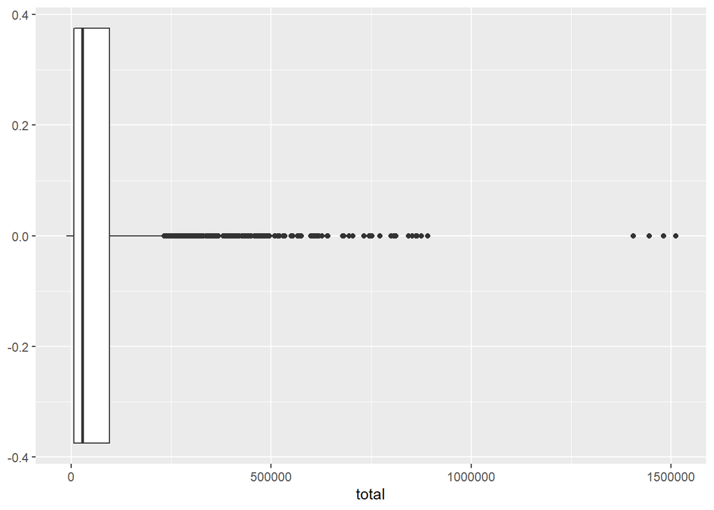

```r
ggplot(pac, aes(total)) +
  geom_boxplot()
```

Another issue is that there are outliers too in the ’total; column of the data set.

```r
pac %>%
  group_by(dems) %>%
  summarize(n = n())
```

```
## # A tibble: 651 x 2
##     dems     n
##    <dbl> <int>
##  1 -4500     1
##  2 -4000     1
##  3 -3000     1
##  4 -1500     1
##  5 -1000     1
##  6  -500     3
##  7  -250     1
##  8     0   390
##  9     1     1
## 10   200     1
## # ... with 641 more rows
```

Another issue is that number of zeros in dems, total and repubs columns is more.

**B**

```r
sum(is.na(pac))
```

```
## [1] 4
```

Aas we can see there are NA’s in the dataset.

```r
pac_no_na <- na.omit(pac)
```

The above chunk is to remove all the NA values in the data set and stores the data into new dataset.

```r
sum(is.na(pac_no_na))
```

```
## [1] 0
```

There no NA’s now in dataset.

**Question 2** **A**

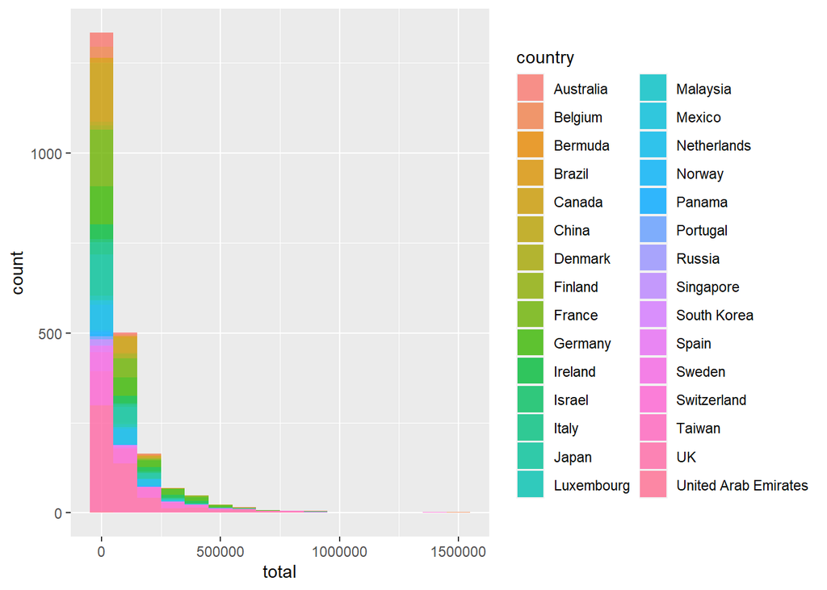

```r
ggplot(data = pac_no_na, mapping = aes(x = total, fill = country)) +
  geom_histogram(binwidth = 100000, alpha = 0.8)
```

As you cans see the graph the the distribution curve goes on decreasing as the value in the column increases.

**B**

```r
pac_smry <- pac_no_na %>%
              summarize(mean_tot = mean(total), st_dev = sd(total))
pac_smry
```

```
## # A tibble: 1 x 2
##   mean_tot  st_dev
##      <dbl>   <dbl>
## 1   80956. 138217.
```

**C**

```r
pac_rpt <- pac_no_na %>%
            group_by(country) %>%
            summarize(total_contri = sum(total), mean_contri = mean(total))
pac_rpt
```

```
## # A tibble: 30 x 3
##    country   total_contri mean_contri
##    <chr>            <dbl>       <dbl>
##  1 Australia      1287113      28603.
##  2 Belgium        6233566     138524.
##  3 Bermuda        1165132     166447.
##  4 Brazil          810250      47662.
##  5 Canada         6644438      31640.
##  6 China           472029      36310.
##  7 Denmark        3082519     102751.
##  8 Finland          34200      34200
##  9 France        10425215      47822.
## 10 Germany       23434340     110539.
## # ... with 20 more rows
```

From the above chunk you can see that the report above displays the total and the mean contribution for each country.

**Question 3**

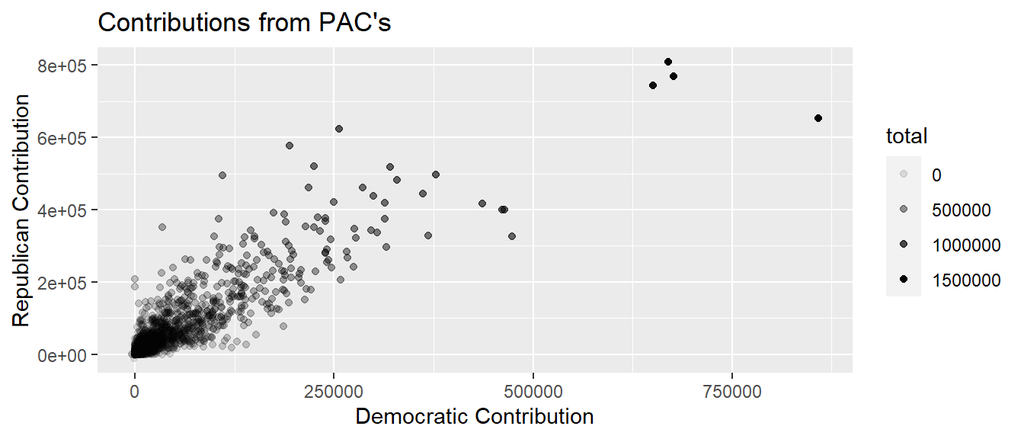

```r
pac_sct <- ggplot(pac, aes(x=dems,y=repubs, alpha = total)) +
                  geom_point()
pac_sct + labs(title = "Contributions from PAC's",
                   x="Democratic Contribution",y="Republican Contribution")
```

as you can see the graph has been replicated as it was asked to. The figure height and the width is also specified.

**Question 4** **A**

```r
plt <- pac_no_na %>%
            select(year, dems, repubs)
plt
```

```
## # A tibble: 2,179 x 3
##     year  dems repubs
##    <dbl> <dbl>  <dbl>
##  1  1998 10775   5000
##  2  1998 19750  28750
##  3  1998  3500  27000
##  4  1998 10100  31600
##  5  1998  8500  22500
##  6  1998 11000  28500
##  7  1998 18060  23923
##  8  1998  1200  10600
##  9  1998  5857    500
## 10  1998     0      0
## # ... with 2,169 more rows
```

```r
bar_plt <- pivot_longer(plt, -year, names_to="variable", values_to="value")
```

In the above chunk I have only selected the dems, repubs and year columns and stored them into a new data frame.Then used pivot longer in order to plot the bar plot. Pivot longer here will exclude the year column and take the rest of the two columns as variables.

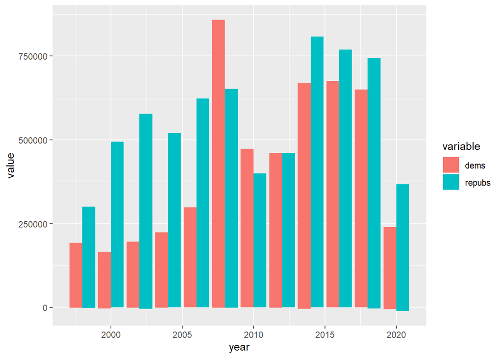

```r
ggplot(bar_plt,aes(x = year,y = value)) +
    geom_bar(aes(fill = variable),stat = "identity",position = "dodge")
```

As you can see int he graph above most of the times Republicans are the ones who were getting more contributions when compared to democrats over the time. Democrats got more contribution only in between the year 2007 to 2010.

**B**

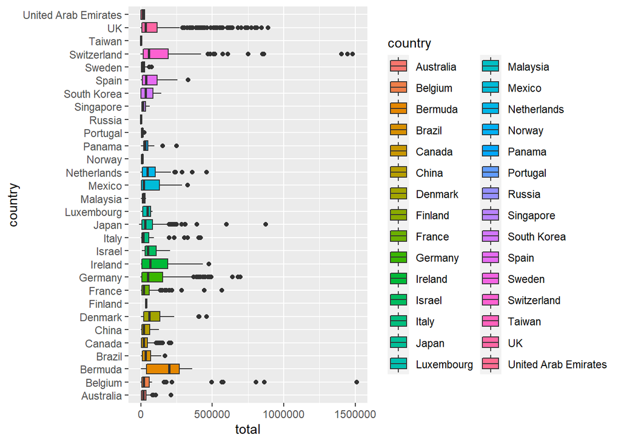

```r
pac_box<-ggplot(pac_no_na, aes(x=total, y=country, fill = country)) +
  geom_boxplot()
pac_box
```

From the box plot above you can see that the UK, Switzerland, Ireland, Germany, Bermuda etc. are the countries which have contributed more than other countries.

**Question 5** Which country has contributed more to Republicans ?

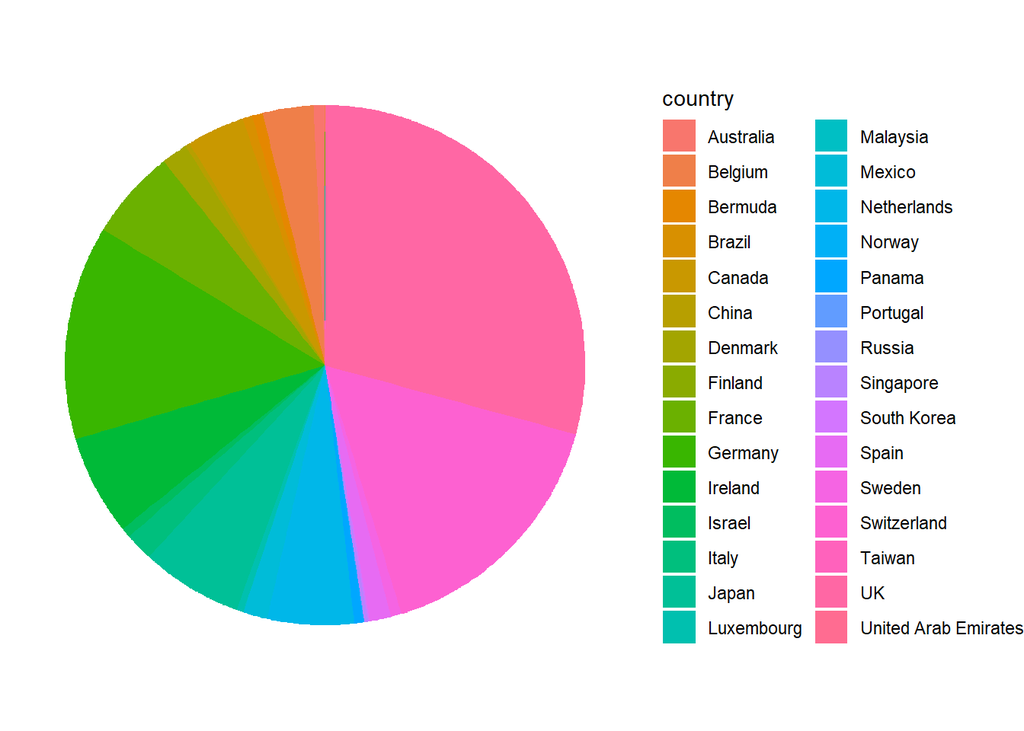

```r
ggplot(pac_no_na, aes(x="", y=repubs, fill=country)) +
  geom_bar(stat="identity", width=1) +
  coord_polar("y", start=0) +
  theme_void()
```

As I wanted to show something with pie plot in the above plot we can see that which country has contributed more to the republicans. UK, Switzerland and Germany are the countries we can say that has contributed more to the Republicans based on the data set.